# hw4.4

## Homework 4.4: Sequence design and structure prediction (20 pts)

This problem explores using full sequence design with varying levels of rotamer resolution to generate sequences using the backbone of Protein G as a template with a course binary pattern.

## Part 1

Load 1pga_prepared_rosetta.pdb in the “Sequence Design” application (“Applications/Structure-based Design/Sequence Design”). Noting the residue classification generated in 4.2.3, setup three “Row Operations”: one for the core residue positions in “Sites” with “Restypes” of “hydrophobic” and “Gly”; one for the boundary residue positions in “Sites” with “Restypes” of “hydrophobic”, “polar”, and “Gly”; and one for the surface residue positions in "Sites” with “Restypes” of “polar” and “Gly”. Check the box for “Write designed sequences to a FASTA file”. Under “3-Input structure selection and preparation settings”, remove the check for “Standardize the input structure” since the structure is already standardized. Under “4-Optimization protocol settings”, set the “Maximum number of solutions to keep” to 1000 and set “Start From” to “StartFrom.Random”. Under “6-Rotamer Library selection and filtering settings”, set the rotamer “Expansion level” to “0” and then “Submit” the job. After the job is completed, download the final .pdb file, the .fasta file and the calculation log. Rename them all to "1pga_rosetta_design" and submit them with your homework.

## Part 2

Run a structure prediction on the lowest energy designed sequence using AlphaFold2 in Colab: https://colab.research.google.com/github/sokrypton/ColabFold/blob/main/AlphaFold2.ipynb. Copy the first sequence in the .fasta file to the “query_sequence” and then select “Runtime/Run all” from the menu bar to start the structure prediction. When the calculation is complete, go to “Display 3D structure” and note the confidence of the structure prediction (pIDDT) displayed on the structure. Make a figure including the structure and the pIDDT scale and insert it into your notebook. Make sure to include the figure file in your homework submission. Unpack the .zip file, rename the PDB file of the top model (model_1) to "AlphaFold2_model_1.pdb" and submit it with your notebook. Load 1pga_prepared_rosetta.pdb and AlphaFold2_model_1.pdb into PyMOL. Display “cartoon” images for both structures in different colors and then “align” the backbone atoms of the structures. Note the RMSD value and make a figure of the aligned structures using a view that highlights the areas of maximum discrepancy. Insert the figure into your notebook and include the figure file with your submission.

RMSD: 0.494, green is Triad, blue is AlphaFold

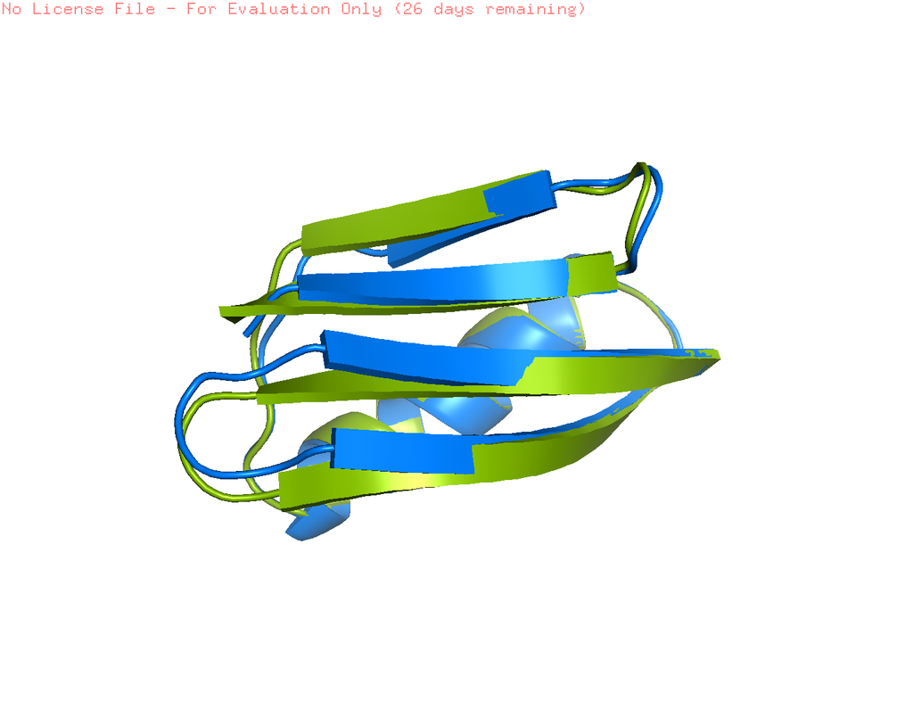

## Part 3

Repeat the sequence design calculation, but with “Start From” set to “StartFrom.Current”, the rotamer “Expansion level” set to 2 and “Add input structure rotamers” checked on. Repeat the structure prediction and analysis including the generation of the figures. Be sure to record the results in your notebook. How have the changes made to the run parameters affected the energies of the best designs, the confidence of the structure prediction, and the match to the predicted structure to the 1pga template? What is an explanation for these changes?

RMSD: 0.431

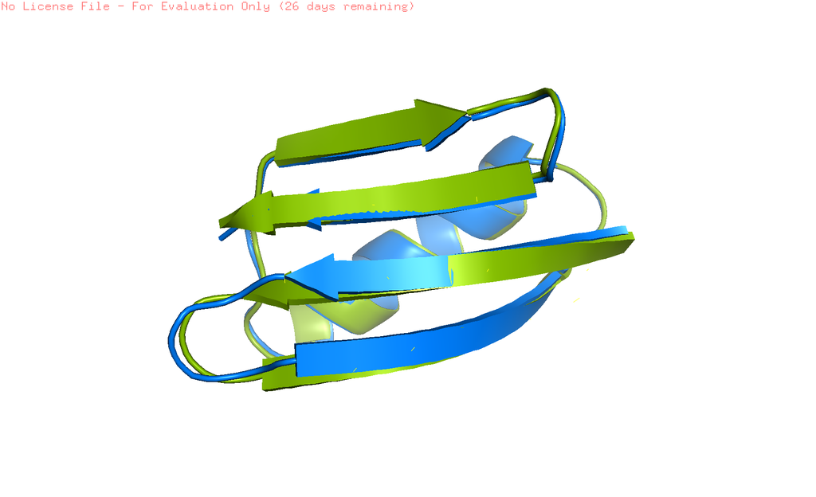

The changes made in the structure design parameters resulted in lower predictied energies for the best designs (-124 v -133). A lower ddG values indictas a more favorable design. The confidence of the AlphaFold strcuture prediction also improved (pIDDT almost all > 90). Furthermore, the match between the AlphaFold and 1pga template was also improved (RMSD decreased). This is likely because we relaxed some of the model constraints for packing the residues. The simulation now more closely resembles the AlphaFold model.